# yli130_5

Yanxi Li

11/19/2020

### ML Assignment_5

### Data Preparation

Since the missing data is not much, remove the missing data.

Changing mfr & type 2 categorical variables into factors.

Renaming the names to be clear in figure and changing the name column to row-names.

```r
# load the libraries needed
library(tidyverse) # data manipulations
library(cluster) # Agglomerative hierarchical clustering
library(factoextra) # clustering algorithm & visualization
library(caret) # split data
library(ggplot2) # plot the figure

# load the data set
data_raw <- read.csv("C:/Users/yanxi/OneDrive/Desktop/Machine Learning Assignment/Assignment#5/Cereals.csv")
# check the missing percentage of every variables
colMeans(is.na(data_raw))
```

```
      name        mfr       type   calories    protein        fat     sodium
0.00000000 0.00000000 0.00000000 0.00000000 0.00000000 0.00000000 0.00000000
     fiber      carbo     sugars     potass   vitamins      shelf     weight
0.00000000 0.01298701 0.01298701 0.02597403 0.00000000 0.00000000 0.00000000
      cups     rating
0.00000000 0.00000000
```

```r
# remove the missing rows since the missing percentage is small
data <- data_raw[complete.cases(data_raw),]
# resetting data-frame index
rownames(data) <- 1: nrow(data)
# check the data structure
str(data)
```

```
'data.frame':   74 obs. of  16 variables:
 $ name    : chr  "100%_Bran" "100%_Natural_Bran" "All-Bran" "All-Bran_with_Extra_Fiber" ...
 $ mfr     : chr  "N" "Q" "K" "K" ...
 $ type    : chr  "C" "C" "C" "C" ...
 $ calories: int  70 120 70 50 110 110 130 90 90 120 ...
 $ protein : int  4 3 4 4 2 2 3 2 3 1 ...
 $ fat     : int  1 5 1 0 2 0 2 1 0 2 ...
 $ sodium  : int  130 15 260 140 180 125 210 200 210 220 ...
 $ fiber   : num  10 2 9 14 1.5 1 2 4 5 0 ...
 $ carbo   : num  5 8 7 8 10.5 11 18 15 13 12 ...
 $ sugars  : int  6 8 5 0 10 14 8 6 5 12 ...
 $ potass  : int  280 135 320 330 70 30 100 125 190 35 ...
 $ vitamins: int  25 0 25 25 25 25 25 25 25 25 ...
 $ shelf   : int  3 3 3 3 1 2 3 1 3 2 ...
 $ weight  : num  1 1 1 1 1 1 1.33 1 1 1 ...
 $ cups    : num  0.33 1 0.33 0.5 0.75 1 0.75 0.67 0.67 0.75 ...
 $ rating  : num  68.4 34 59.4 93.7 29.5 ...
```

```r
# transfer character variables to factor
data$mfr <- as.factor(data$mfr)
data$type <- as.factor(data$type)
# shorten row-names
data[2,1] <- "100%_Natural"
data[4,1] <- "All-Bran_with"
data[5,1] <- "Apple_Cinnamon"
data[12,1] <- "Cinnamon_Toast"
data[19,1] <- "Cracklin'_Oat"
data[21,1] <- "Crispy_Wheat"
data[25,1] <- "Frosted_Mini"
data[26,1] <- "Fruit_&_Fibre"
data[33,1] <- "Great_Grains"
data[37,1] <- "Just_Right_Crunc"
data[38,1] <- "Just_Right_Fruit"
data[43,1] <- "Muesli_Raisins_D"
data[44,1] <- "Muesli_Raisins_P"
data[45,1] <- "Mueslix_Crispy"
data[46,1] <- "Multi-Grain"
data[48,1] <- "Nutri-Grain_Al"
data[49,1] <- "Nutri-grain_Wh"
data[50,1] <- "Oatmeal_Raisin"
data[51,1] <- "Post_Nat._R"
data[62,1] <- "Shred_Wheat_n"
data[63,1] <- "Shred_Wheat_s"
data[66,1] <- "Strawberry_Fru"
data[74,1] <- "Wheaties_Honey"
data[35,1] <- "Honey_Nut"
data[55,1] <- "Quaker_Oat"
data[47,1] <- "Nut&Honey"
data[34,1] <- "Honey_Graham"
# set row names to the data column
row.names(data) <- data[,1]
# remove the name column
data <- data[,-1]
# show first 3 rows of data
head(data, 3)
```

```
             mfr type calories protein fat sodium fiber carbo sugars potass
100%_Bran      N    C       70       4   1    130    10     5      6    280
100%_Natural   Q    C      120       3   5     15     2     8      8    135
All-Bran       K    C       70       4   1    260     9     7      5    320
             vitamins shelf weight cups   rating
100%_Bran          25     3      1 0.33 68.40297
100%_Natural        0     3      1 1.00 33.98368
All-Bran           25     3      1 0.33 59.42551
```

```r
# show the descriptive statistics
summary(data)
```

```
 mfr    type      calories      protein           fat        sodium
 A: 1   C:73   Min.   : 50   Min.   :1.000   Min.   :0   Min.   :  0.0
 G:22   H: 1   1st Qu.:100   1st Qu.:2.000   1st Qu.:0   1st Qu.:135.0
 K:23          Median :110   Median :2.500   Median :1   Median :180.0
 N: 5          Mean   :107   Mean   :2.514   Mean   :1   Mean   :162.4
 P: 9          3rd Qu.:110   3rd Qu.:3.000   3rd Qu.:1   3rd Qu.:217.5
 Q: 7          Max.   :160   Max.   :6.000   Max.   :5   Max.   :320.0
 R: 7
     fiber            carbo           sugars           potass
 Min.   : 0.000   Min.   : 5.00   Min.   : 0.000   Min.   : 15.00
 1st Qu.: 0.250   1st Qu.:12.00   1st Qu.: 3.000   1st Qu.: 41.25
 Median : 2.000   Median :14.50   Median : 7.000   Median : 90.00
 Mean   : 2.176   Mean   :14.73   Mean   : 7.108   Mean   : 98.51
 3rd Qu.: 3.000   3rd Qu.:17.00   3rd Qu.:11.000   3rd Qu.:120.00
 Max.   :14.000   Max.   :23.00   Max.   :15.000   Max.   :330.00

    vitamins          shelf           weight           cups
 Min.   :  0.00   Min.   :1.000   Min.   :0.500   Min.   :0.2500
 1st Qu.: 25.00   1st Qu.:1.250   1st Qu.:1.000   1st Qu.:0.6700
 Median : 25.00   Median :2.000   Median :1.000   Median :0.7500
 Mean   : 29.05   Mean   :2.216   Mean   :1.031   Mean   :0.8216
 3rd Qu.: 25.00   3rd Qu.:3.000   3rd Qu.:1.000   3rd Qu.:1.0000
 Max.   :100.00   Max.   :3.000   Max.   :1.500   Max.   :1.5000

     rating
 Min.   :18.04
 1st Qu.:32.45
 Median :40.25
 Mean   :42.37
 3rd Qu.:50.52
 Max.   :93.70
```

### Apply Hierarchical Clustering with Agnes

Use Agnes to compare the clustering from single linkage, complete linkage, average linkage, and Ward.

Agnes() function can also get the agglomerative coefficient.

We choose the higher coefficient value because the value closer to 1 suggest strong clustering structure.

```r
# copy the data
data_norm <- data
# normalize the numerical variables
data_norm[,c(3:15)] <- scale(data[,c(3:15)])
# check the normalized data
head(data_norm, 3)
```

```
             mfr type   calories   protein      fat     sodium       fiber
100%_Bran      N    C -1.8659155 1.3817478 0.000000 -0.3910227  3.22866747
100%_Natural   Q    C  0.6537514 0.4522084 3.972881 -1.7804186 -0.07249167
All-Bran       K    C -1.8659155 1.3817478 0.000000  1.1795987  2.81602258
                 carbo     sugars    potass   vitamins     shelf     weight
100%_Bran    -2.500140 -0.2542051 2.5605229 -0.1818422 0.9419715 -0.2008324
100%_Natural -1.729263  0.2046041 0.5147738 -1.3032024 0.9419715 -0.2008324
All-Bran     -1.986222 -0.4836096 3.1248675 -0.1818422 0.9419715 -0.2008324
                   cups     rating
100%_Bran    -2.0856582  1.8549038
100%_Natural  0.7567534 -0.5977113
All-Bran     -2.0856582  1.2151965
```

```r
# Compute with Agnes and different linkage methods
hc_single <- agnes(data_norm, method = "single")
hc_complete <- agnes(data_norm, method = "complete")
hc_average <- agnes(data_norm, method = "average")
hc_ward <- agnes(data_norm, method = "ward")
# Compare Agglomerative coefficients
hc_single$ac
```

```
[1] 0.5994135
```

```r
hc_complete$ac
```

```
[1] 0.8310628
```

```r
hc_average$ac
```

```
[1] 0.7559274
```

```r
hc_ward$ac  # the best linkage method which is 0.8993694
```

```
[1] 0.8993694
```

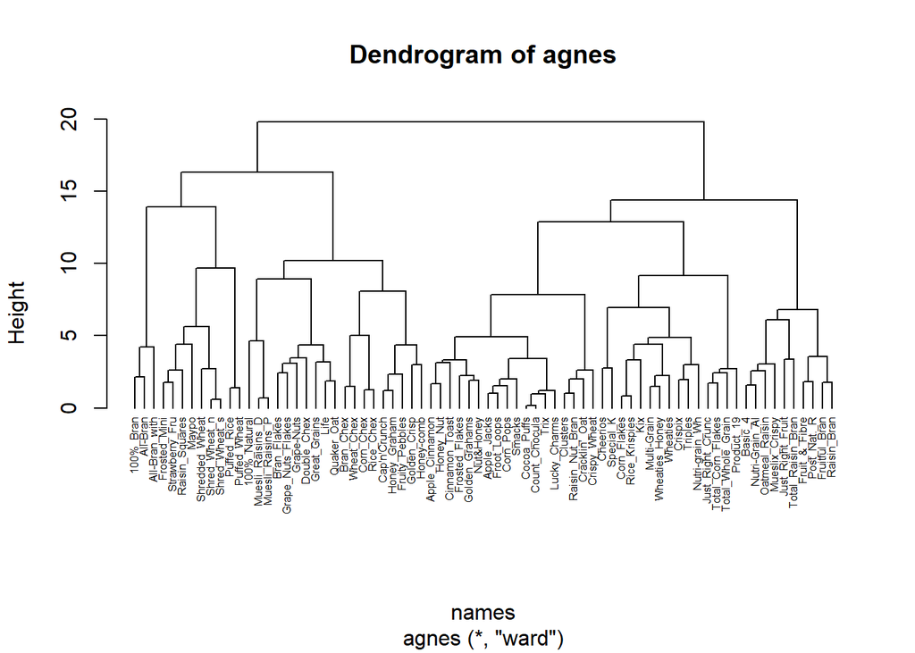

```r
# plot the dendrogram
pltree(hc_ward, cex = 0.5, hang = -1, main = "Dendrogram of agnes", xlab = "names")
```

Since the Ward’s Agglomerative coefficient is the highest(0.8993694), I choose the Ward method to plot the dendrogram.

### Choose numbers of clusters

I use the Elbow & Silhouette methods like the K-means clustering but changing FUN to “hcut” which means hierarchical clustering.

Since the Elbow method is not obvious, I choose the Silhouette highest point which is 10 to be my cluster numbers.

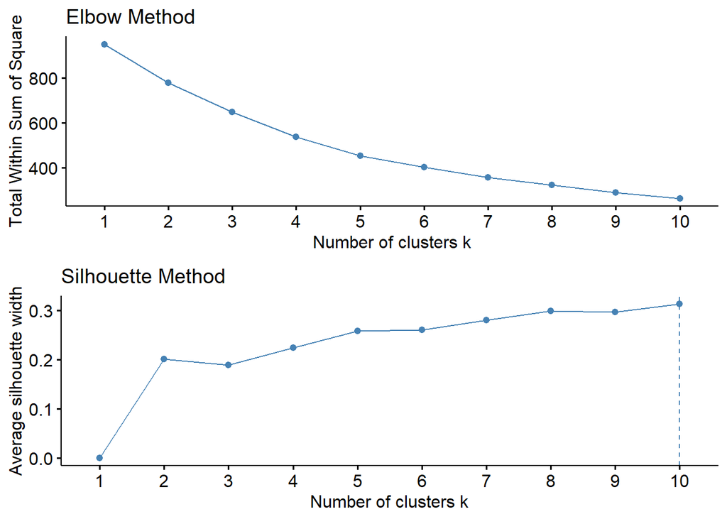

```r
# use the Elbow Method to find the cluster numbers
p1 <- fviz_nbclust(data_norm[,c(3:15)], FUN = hcut, method = "wss", k.max = 10) +   #  hcut means hierarchical clustering
    ggtitle("Elbow Method")
# use the Silhouette Method to find the cluster numbers
p2 <- fviz_nbclust(data_norm[,c(3:15)], FUN = hcut, method = "silhouette", k.max = 10) +
    ggtitle("Silhouette Method")
# display different methods' plots together
gridExtra::grid.arrange(p1, p2)
```

```r
# cut cluster numbers to be 10
clusters <- cutree(hc_ward, k = 10)
# show each cluster's size
table(clusters)
```

```
clusters
 1  2  3  4  5  6  7  8  9 10
 3  3 18 10  9  7 11  7  4  2
```

```r
# use cutree output to add the cluster observations belongs to original data
data_norm$cluster <- clusters
# change cluster variable into factor
data_norm$cluster <- as.factor(data_norm$cluster)
# show first 3 rows for data frame add cluster
head(data_norm, 3)
```

```
             mfr type   calories   protein      fat     sodium       fiber
100%_Bran      N    C -1.8659155 1.3817478 0.000000 -0.3910227  3.22866747
100%_Natural   Q    C  0.6537514 0.4522084 3.972881 -1.7804186 -0.07249167
All-Bran       K    C -1.8659155 1.3817478 0.000000  1.1795987  2.81602258
                 carbo     sugars    potass   vitamins     shelf     weight
100%_Bran    -2.500140 -0.2542051 2.5605229 -0.1818422 0.9419715 -0.2008324
100%_Natural -1.729263  0.2046041 0.5147738 -1.3032024 0.9419715 -0.2008324
All-Bran     -1.986222 -0.4836096 3.1248675 -0.1818422 0.9419715 -0.2008324
                   cups     rating cluster
100%_Bran    -2.0856582  1.8549038       1
100%_Natural  0.7567534 -0.5977113       2
All-Bran     -2.0856582  1.2151965       1
```

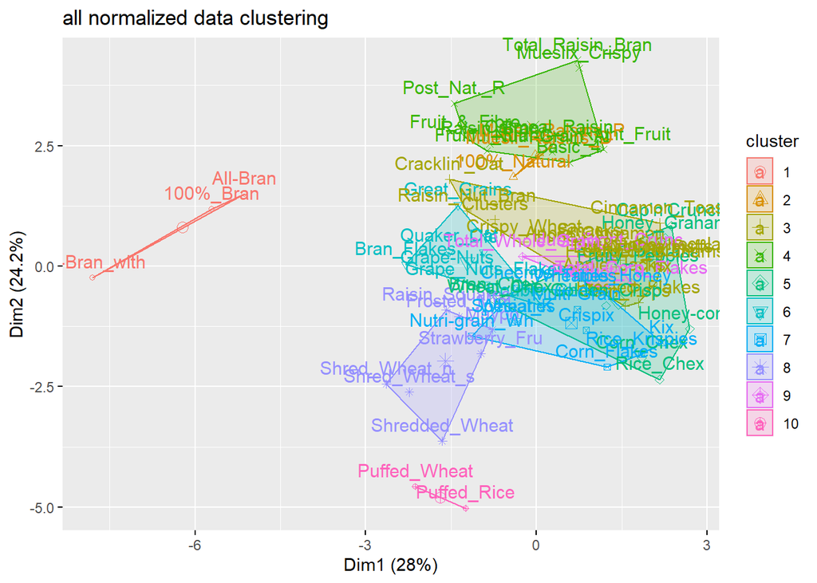

```r
# visual the 10 clusters
fviz_cluster(list(data = data_norm[,c(3:15)], cluster = clusters)) +
  ggtitle("all normalized data clustering")
```

### Cluster Stability

I remove 15% of the data to check the stability. For the rest 85% data, run hierarchical clustering again, and see if the clusters have shifted.

```r
# make sure choose the same data set every time
set.seed(123)
# choose 85% data
Index_partition <- createDataPartition(data$rating, p = 0.85, list = F)
Partition_data <- data[Index_partition,] # 85% data
Rest_data <- data[-Index_partition,]  # rest data
# copy the data
Partition_data_norm <- Partition_data
# normalize the 85% data
Partition_data_norm[,c(3:15)] <- scale(Partition_data[,c(3:15)])
# show the first 3 rows
head(Partition_data_norm, 3)
```

```
             mfr type   calories   protein         fat     sodium       fiber
100%_Bran      N    C -1.9452536 1.3419634 -0.04416101 -0.4222274  3.98692724
100%_Natural   Q    C  0.6122511 0.4193636  3.84200808 -1.8065495 -0.03043456
All-Bran       K    C -1.9452536 1.3419634 -0.04416101  1.1426585  3.48475702
                 carbo     sugars   potass   vitamins     shelf     weight
100%_Bran    -2.575852 -0.2640792 2.766677 -0.2113805 0.8932256 -0.1922659
100%_Natural -1.787569  0.2134338 0.578487 -1.2845430 0.8932256 -0.1922659
All-Bran     -2.050330 -0.5028356 3.370316 -0.2113805 0.8932256 -0.1922659
                   cups     rating
100%_Bran    -2.0480022  2.1316234
100%_Natural  0.7454172 -0.6192496
All-Bran     -2.0480022  1.4141225
```

```r
# Compute with agnes and different linkage methods
hc_single_partition <- agnes(Partition_data_norm, method = "single")
hc_complete_partition <- agnes(Partition_data_norm, method = "complete")
hc_average_partition <- agnes(Partition_data_norm, method = "average")
hc_ward_partition <- agnes(Partition_data_norm, method = "ward")
# Compare Agglmerative coefficients
hc_single_partition$ac
```

```
[1] 0.5765981
```

```r
hc_complete_partition$ac
```

```
[1] 0.821389
```

```r
hc_average_partition$ac
```

```
[1] 0.7336505
```

```r
hc_ward_partition$ac     # the best linkage method, 0.8857997
```

```
[1] 0.8857997
```

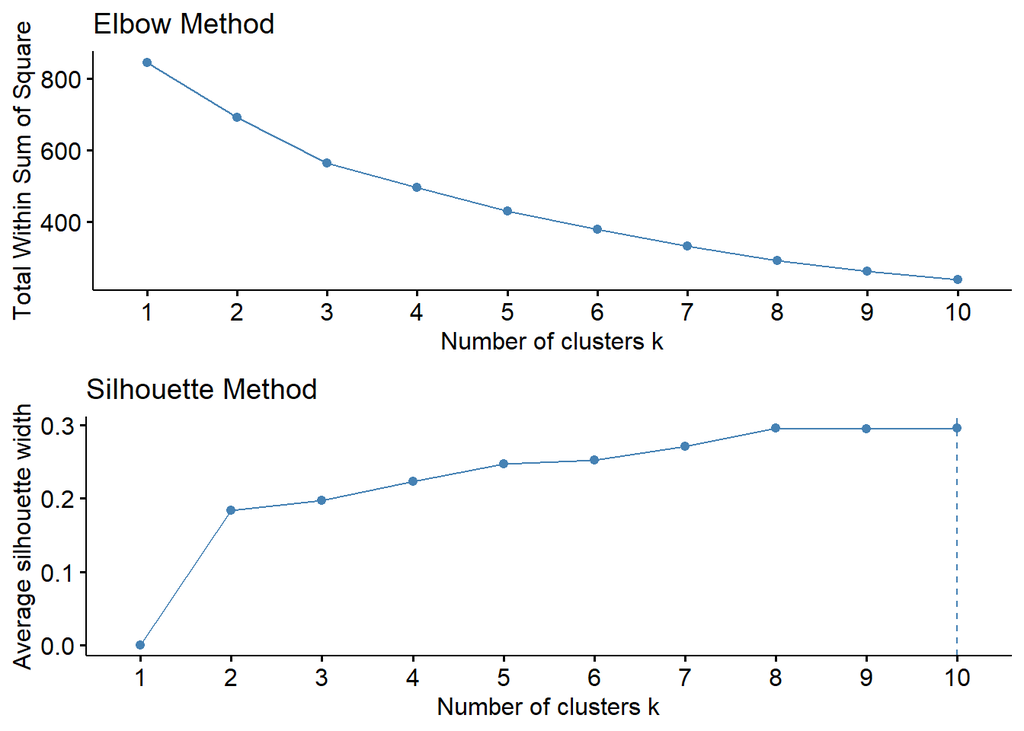

```r
# use the Elbow Method to find the cluster numbers
p1_partition <- fviz_nbclust(Partition_data_norm[,c(3:15)], FUN = hcut, method = "wss", k.max = 10) +   # hcut means hierarchical clustering
    ggtitle("Elbow Method")
# use the Silhouette Method to find the cluster numbers
p2_partition <- fviz_nbclust(Partition_data_norm[,c(3:15)], FUN = hcut, method = "silhouette", k.max = 10) +
    ggtitle("Silhouette Method")
# display plots together
gridExtra::grid.arrange(p1_partition, p2_partition)
```

```r
# choose cluster number equals to 10
clusters_partition <- cutree(hc_ward_partition, k = 10)
# show every cluster's size
table(clusters_partition)
```

```
clusters_partition
 1  2  3  4  5  6  7  8  9 10
 2  3 17  9 10 10  4  5  4  2
```

```r
# add cluster to Partition data
Partition_data_norm$cluster <- clusters_partition
# change cluster variable into factor
Partition_data_norm$cluster <- as.factor(Partition_data_norm$cluster)
# show first 3 rows for data frame add cluster
head(Partition_data_norm, 3)
```

```
             mfr type   calories   protein         fat     sodium       fiber
100%_Bran      N    C -1.9452536 1.3419634 -0.04416101 -0.4222274  3.98692724
100%_Natural   Q    C  0.6122511 0.4193636  3.84200808 -1.8065495 -0.03043456
All-Bran       K    C -1.9452536 1.3419634 -0.04416101  1.1426585  3.48475702
                 carbo     sugars   potass   vitamins     shelf     weight
100%_Bran    -2.575852 -0.2640792 2.766677 -0.2113805 0.8932256 -0.1922659
100%_Natural -1.787569  0.2134338 0.578487 -1.2845430 0.8932256 -0.1922659
All-Bran     -2.050330 -0.5028356 3.370316 -0.2113805 0.8932256 -0.1922659
                   cups     rating cluster
100%_Bran    -2.0480022  2.1316234       1
100%_Natural  0.7454172 -0.6192496       2
All-Bran     -2.0480022  1.4141225       1
```

```r
# compare the cluster changing
rownames(data_norm)[clusters == 1]   # cluster 1 for all data
```

```
[1] "100%_Bran"     "All-Bran"      "All-Bran_with"
```

```r
rownames(Partition_data_norm)[clusters_partition == 1]   # cluster 1 for 85% split data
```

```
[1] "100%_Bran" "All-Bran"
```

```r
rownames(data_norm)[clusters == 2]   # cluster 2 for all data
```

```
[1] "100%_Natural"     "Muesli_Raisins_D" "Muesli_Raisins_P"
```

```r
rownames(Partition_data_norm)[clusters_partition == 2]   # cluster 2 for 85% split data
```

```
[1] "100%_Natural"     "Muesli_Raisins_D" "Muesli_Raisins_P"
```

```r
rownames(data_norm)[clusters == 3]   # cluster 3 for all data
```

```
 [1] "Apple_Cinnamon"  "Apple_Jacks"     "Cinnamon_Toast"  "Clusters"
 [5] "Cocoa_Puffs"     "Corn_Pops"       "Count_Chocula"   "Cracklin'_Oat"
 [9] "Crispy_Wheat"    "Froot_Loops"     "Frosted_Flakes"  "Golden_Grahams"
[13] "Honey_Nut"       "Lucky_Charms"    "Nut&Honey"       "Raisin_Nut_Bran"
[17] "Smacks"          "Trix"
```

```r
rownames(Partition_data_norm)[clusters_partition == 3]   # cluster 3 for 85% split data
```

```
 [1] "Apple_Cinnamon" "Apple_Jacks"    "Cap'n'Crunch"   "Cinnamon_Toast"
 [5] "Cocoa_Puffs"    "Corn_Pops"      "Count_Chocula"  "Froot_Loops"
 [9] "Frosted_Flakes" "Golden_Grahams" "Honey_Graham"   "Honey_Nut"
[13] "Honey-comb"     "Nut&Honey"      "Smacks"         "Trix"
[17] "Wheaties_Honey"
```

```r
rownames(data_norm)[clusters == 4]   # cluster 4 for all data
```

```
 [1] "Basic_4"           "Fruit_&_Fibre"     "Fruitful_Bran"
 [4] "Just_Right_Fruit"  "Mueslix_Crispy"    "Nutri-Grain_Al"
 [7] "Oatmeal_Raisin"    "Post_Nat._R"       "Raisin_Bran"
[10] "Total_Raisin_Bran"
```

```r
rownames(Partition_data_norm)[clusters_partition == 4]   # cluster 4 for 85% split data
```

```
[1] "Basic_4"           "Fruitful_Bran"     "Just_Right_Fruit"
[4] "Mueslix_Crispy"    "Nutri-Grain_Al"    "Oatmeal_Raisin"
[7] "Post_Nat._R"       "Raisin_Bran"       "Total_Raisin_Bran"
```

```r
rownames(data_norm)[clusters == 5]   # cluster 5 for all data
```

```
[1] "Bran_Chex"      "Cap'n'Crunch"   "Corn_Chex"      "Fruity_Pebbles"
[5] "Golden_Crisp"   "Honey_Graham"   "Honey-comb"     "Rice_Chex"
[9] "Wheat_Chex"
```

```r
rownames(Partition_data_norm)[clusters_partition == 5]   # cluster 5 for 85% split data
```

```
 [1] "Bran_Chex"         "Bran_Flakes"       "Corn_Chex"
 [4] "Double_Chex"       "Grape_Nuts_Flakes" "Grape-Nuts"
 [7] "Great_Grains"      "Life"              "Quaker_Oat"
[10] "Wheat_Chex"
```

```r
rownames(data_norm)[clusters == 6]   # cluster 6 for all data
```

```
[1] "Bran_Flakes"       "Double_Chex"       "Grape_Nuts_Flakes"
[4] "Grape-Nuts"        "Great_Grains"      "Life"
[7] "Quaker_Oat"
```

```r
rownames(Partition_data_norm)[clusters_partition == 6]   # cluster 6 for 85% split data
```

```
 [1] "Cheerios"       "Corn_Flakes"    "Crispix"        "Kix"
 [5] "Maypo"          "Nutri-grain_Wh" "Rice_Krispies"  "Special_K"
 [9] "Triples"        "Wheaties"
```

```r
rownames(data_norm)[clusters == 7]   # cluster 7 for all data
```

```
 [1] "Cheerios"       "Corn_Flakes"    "Crispix"        "Kix"
 [5] "Multi-Grain"    "Nutri-grain_Wh" "Rice_Krispies"  "Special_K"
 [9] "Triples"        "Wheaties"       "Wheaties_Honey"
```

```r
rownames(Partition_data_norm)[clusters_partition == 7]   # cluster 7 for 85% split data
```

```
[1] "Clusters"        "Cracklin'_Oat"   "Crispy_Wheat"    "Raisin_Nut_Bran"
```

```r
rownames(data_norm)[clusters == 8]   # cluster 8 for all data
```

```
[1] "Frosted_Mini"   "Maypo"          "Raisin_Squares" "Shredded_Wheat"
[5] "Shred_Wheat_n"  "Shred_Wheat_s"  "Strawberry_Fru"
```

```r
rownames(Partition_data_norm)[clusters_partition == 8]   # cluster 8 for 85% split data
```

```
[1] "Frosted_Mini"   "Raisin_Squares" "Shredded_Wheat" "Shred_Wheat_s"
[5] "Strawberry_Fru"
```

```r
rownames(data_norm)[clusters == 9]   # cluster 9 for all data
```

```
[1] "Just_Right_Crunc"  "Product_19"        "Total_Corn_Flakes"
[4] "Total_Whole_Grain"
```

```r
rownames(Partition_data_norm)[clusters_partition == 9]   # cluster 9 for 85% split data
```

```
[1] "Just_Right_Crunc"  "Product_19"        "Total_Corn_Flakes"
[4] "Total_Whole_Grain"
```

```r
rownames(data_norm)[clusters == 10]  # cluster 10 for all data
```

```
[1] "Puffed_Rice"  "Puffed_Wheat"
```

```r
rownames(Partition_data_norm)[clusters_partition == 10]  # cluster 10 for 85% split data
```

```
[1] "Puffed_Rice"  "Puffed_Wheat"
```

After remove 15% of data, run hierarchical clustering again and remove the rest 8 names in 100% data-set, I compare 10 clusters’ items.

I also found use the caret to split 85% data, the actual partition data rows is 66 which means I actually have 90% split data. And remove 10% data is really small which can also caused so many differences in the 2 clusters.

Above all, this cluster’s stability is low.

### Healthy Cereals

Since we want to choose the healthy diet for public schools, the actual value matters. In this case , we do not need to normalize the data.

I run the hierarchical clustering again and also use Elbow & Silhouette method to determine the cluster numbers. They both show 3 is the appropriate numbers of cluster.

I calculate each clusters centers and plot the figure to find the “healthy cereals” cluster.

```r
# Compute with Agnes and different linkage methods
hc_single_new <- agnes(data, method = "single")
hc_complete_new <- agnes(data, method = "complete")
hc_average_new <- agnes(data, method = "average")
hc_ward_new <- agnes(data, method = "ward")
# Compare Agglomerative coefficients
hc_single_new$ac
```

```
[1] 0.7297141
```

```r
hc_complete_new$ac
```

```
[1] 0.9225732
```

```r
hc_average_new$ac
```

```
[1] 0.8786692
```

```r
hc_ward_new$ac       # the best linkage method, 0.959504
```

```
[1] 0.959504
```

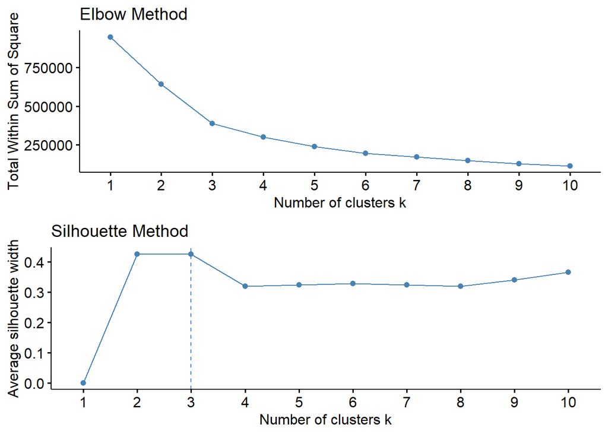

```r
# use the Elbow Method to find the cluster numbers
p1_new <- fviz_nbclust(data[,c(3:15)], FUN = hcut, method = "wss", k.max = 10) +   #  hcut means hierarchical clustering
    ggtitle("Elbow Method")
# use the Silhouette Method to find the cluster numbers
p2_new <- fviz_nbclust(data[,c(3:15)], FUN = hcut, method = "silhouette", k.max = 10) +
    ggtitle("Silhouette Method")
# display plots together
gridExtra::grid.arrange(p1_new, p2_new)   # choose cluster = 3
```

```r
# choose numbers of cluster equal to 3
clusters_new <- cutree(hc_ward_new, k = 3)
# show each cluster size
table(clusters_new)
```

```
clusters_new
 1  2  3
14 10 50
```

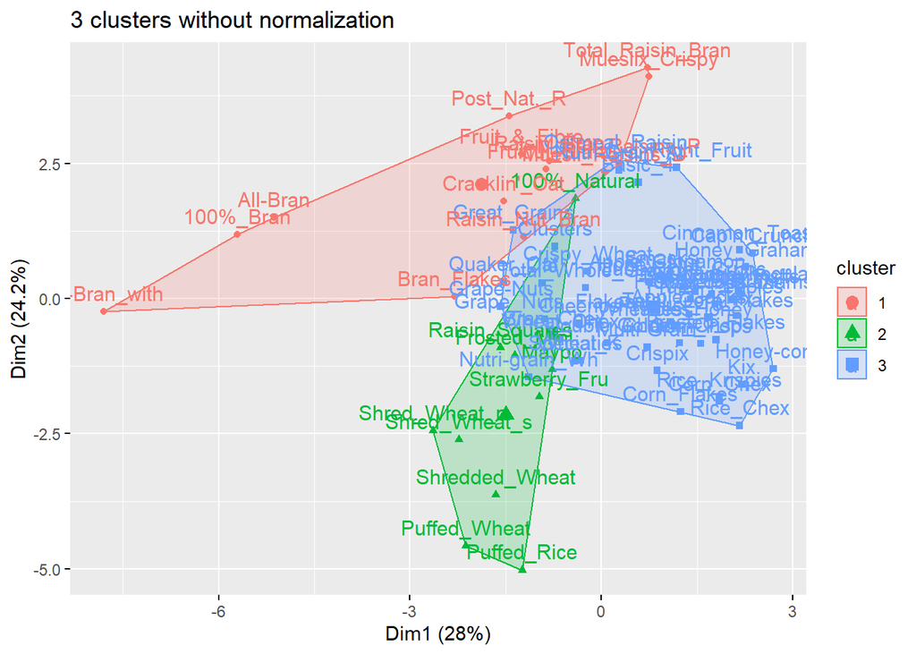

```r
# visual 3 clusters
fviz_cluster(list(data = data[,c(3:15)], cluster = clusters_new)) +
  ggtitle("3 clusters without normalization")
```

```r
# calculate each cluster's centroids
clusters_center_new <- aggregate(data[,c(3:15)], list(cluster = clusters_new), mean)
clusters_center_new
```

```
  cluster calories  protein      fat sodium    fiber    carbo   sugars   potass
1       1 112.1429 3.357143 1.428571  172.5 5.607143 12.03571 9.142857 217.1429
2       2  86.0000 2.500000 0.600000    3.0 2.100000 14.60000 2.900000  95.0000
3       3 109.8000 2.280000 0.960000  191.4 1.230000 15.51000 7.380000  66.0000
  vitamins    shelf weight      cups   rating
1 30.35714 2.928571 1.1600 0.6614286 46.01532
2 10.00000 2.100000 0.8830 0.8640000 60.11492
3 32.50000 2.040000 1.0242 0.8580000 37.80297
```

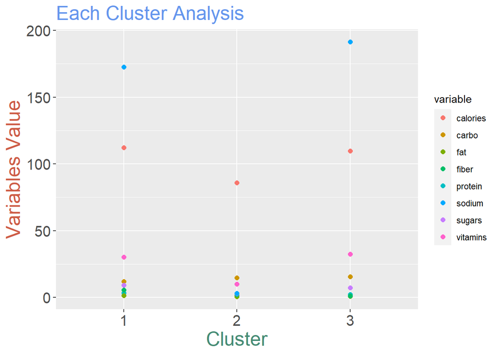

```r
# transfer cluster into factor
clusters_center_new$cluster <- factor(clusters_center_new$cluster)
# use the pivot_longer to make variables together
center_vari_plot <- clusters_center_new %>% select(cluster, calories, protein, fat, fiber, carbo, sugars, sodium, vitamins) %>% pivot_longer(-cluster, names_to = "variable", values_to = "value")
# use ggplot to plot the figure
q <- ggplot(center_vari_plot, aes(cluster, value, colour = variable)) + geom_point(size = 2)
q + xlab("Cluster") +    # name x axis
    ylab("Variables Value") + # name y axis
    ggtitle("Each Cluster Analysis") +   # name the figure title
    theme(axis.title.x = element_text(color="aquamarine4", size=20), # change x axis name's color and size
          axis.title.y = element_text(color="coral3", size=20),   # change y axis name's color and size
          axis.text.x = element_text(size=15),   # change x axis number's size
          axis.text.y = element_text(size=15),   # change y axis number's size
          plot.title = element_text(color="cornflowerblue", size=20))   # change title's color and size
```

```r
# show healthy cereals cluster items
rownames(data)[clusters_new == 2]
```

```
 [1] "100%_Natural"   "Frosted_Mini"   "Maypo"          "Puffed_Rice"
 [5] "Puffed_Wheat"   "Raisin_Squares" "Shredded_Wheat" "Shred_Wheat_n"
 [9] "Shred_Wheat_s"  "Strawberry_Fru"
```

We know that the healthy food usually have low sodium, so I choose Cluster 2 to be the “healthy cereals”.

The 10 items fullnames in Cluster 2 is : “100%*Natural_Bran", "Frosted_Mini_Wheats", "Maypo", "Puffed_Rice", "Puffed_Wheat", "Raisin_Squares", "Shredded_Wheat", "Shredded_Wheat*’n’Bran”, “Shredded_Wheat_spoon_size” and “Strawberry_Fruit_Wheats”.

### Differences between Hierarchical & K-Means

The mainly differences between the Hierarchical & K-means clustering is when to determine the k(number of clusters) value.

K-means is method of cluster analysis using the pre-specified No. of clusters and it requires advance knowledge of k. Hierarchical clustering is also a method of cluster analysis which builds a hierarchy of clusters without knowing k.

In K Means clustering, since it start with random choice of clusters, the results produced by running the algorithm many times may differ. While in Hierarchical clustering, results are reproducible with differences k choices.

Hierarchical clustering can build the dendrogram. While for the K-means, it can only plot each set of data into non-overlapping clusters.

The advantages for hierarchical cluster : the dendrogram is more informative than K-means and easy to decide k value on by looking at the dendrogram.